# Assignment 5

Coefficients: (Intercept) sexMale faculty_rankAsstProf  
80988.47 4349.37 -13104.15  
faculty_rankProf years_since_phd disciplineB  
32928.40 61.01 13937.47

```r
summary(salary_lm2)
```

Call: lm(formula = salary ~ sex + faculty_rank + years_since_phd + discipline, data = faculty_salary)

Residuals: Min 1Q Median 3Q Max -67451 -13860 -1549 10716 97023

Coefficients: Estimate Std. Error t value Pr(>|t|)  
(Intercept) 80988.47 4931.84 16.422 < 2e-16 sexMale 4349.37 3875.39 1.122 0.26242  
faculty_rankAsstProf -13104.15 4167.31 -3.145 0.00179 faculty_rankProf 32928.40 3544.40 9.290 < 2e-16 years_since_phd 61.01 127.01 0.480 0.63124  
disciplineB 13937.47 2346.53 5.940 6.32e-09 * — Signif. codes: 0 ‘**’ 0.001 ’**’ 0.01 ’’ 0.05 ‘.’ 0.1 ‘’ 1

Residual standard error: 22660 on 391 degrees of freedom Multiple R-squared: 0.4472, Adjusted R-squared: 0.4401 F-statistic: 63.27 on 5 and 391 DF, p-value: < 2.2e-16

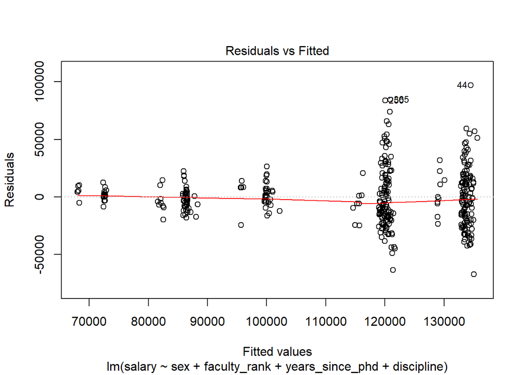

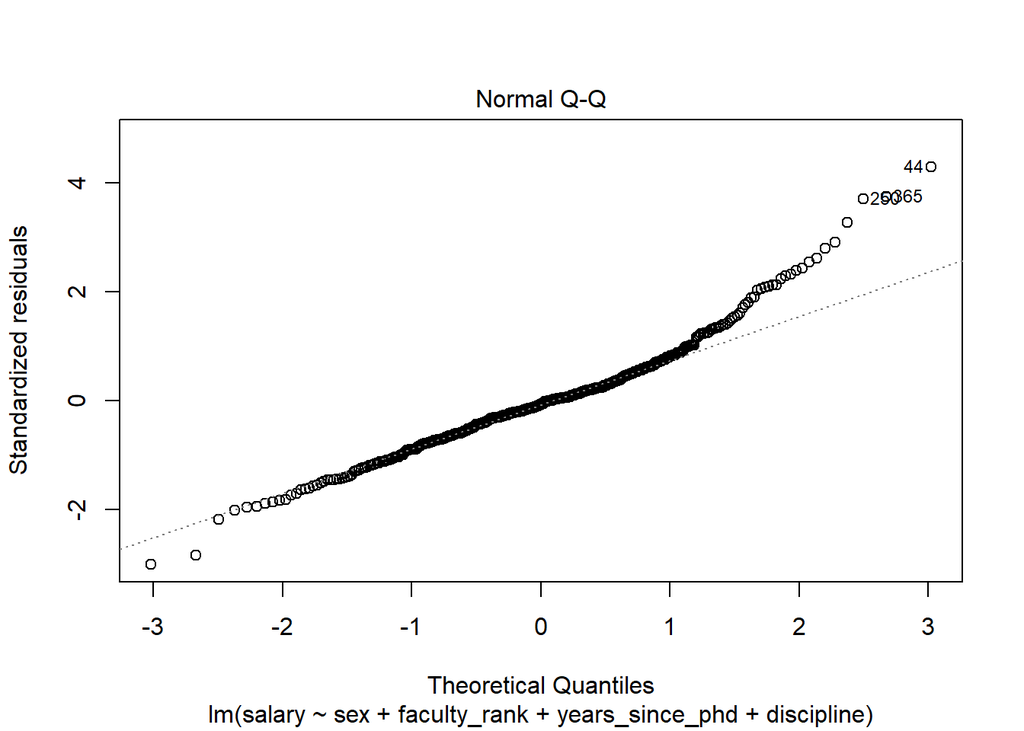

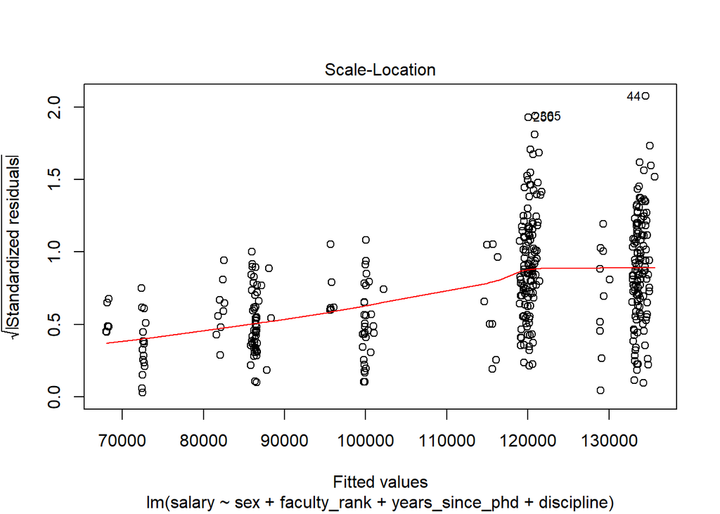

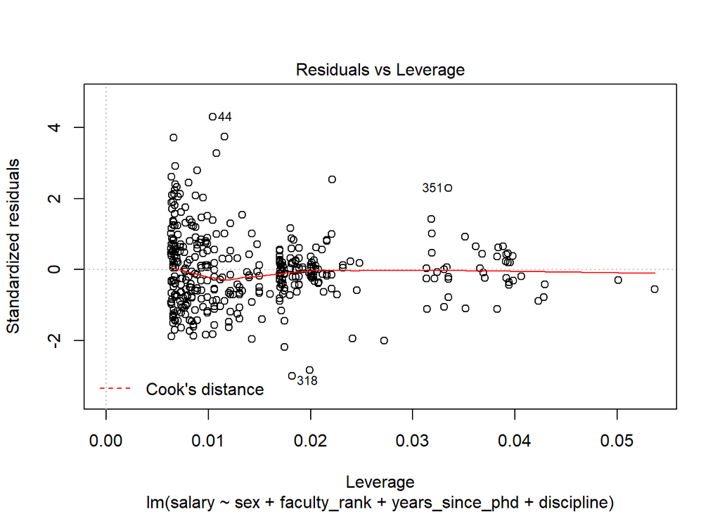

```r
plot(salary_lm2)
```

```r
#Try without years of service OR years since PhD??

salary_lm3 <- lm(salary ~ sex + faculty_rank + discipline, data = faculty_salary)
salary_lm3
```

Call: lm(formula = salary ~ sex + faculty_rank + discipline, data = faculty_salary)

Coefficients: (Intercept) sexMale faculty_rankAsstProf  
81947 4492 -13723  
faculty_rankProf disciplineB  
33680 13709

```r
summary(salary_lm3)
```

Call: lm(formula = salary ~ sex + faculty_rank + discipline, data = faculty_salary)

Residuals: Min 1Q Median 3Q Max -66268 -14127 -1566 10813 97718

Coefficients: Estimate Std. Error t value Pr(>|t|)  
(Intercept) 81947 4506 18.187 < 2e-16 sexMale 4492 3860 1.164 0.245291  
faculty_rankAsstProf -13723 3959 -3.466 0.000586 faculty_rankProf 33680 3177 10.600 < 2e-16 *disciplineB 13709 2295 5.972 5.25e-09* — Signif. codes: 0 ‘**’ 0.001 ’**’ 0.01 ’’ 0.05 ‘.’ 0.1 ‘’ 1

Residual standard error: 22640 on 392 degrees of freedom Multiple R-squared: 0.4469, Adjusted R-squared: 0.4412 F-statistic: 79.18 on 4 and 392 DF, p-value: < 2.2e-16

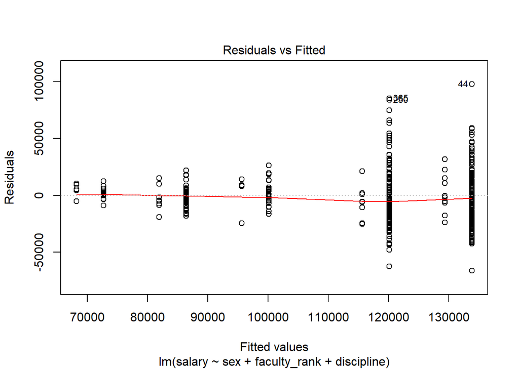

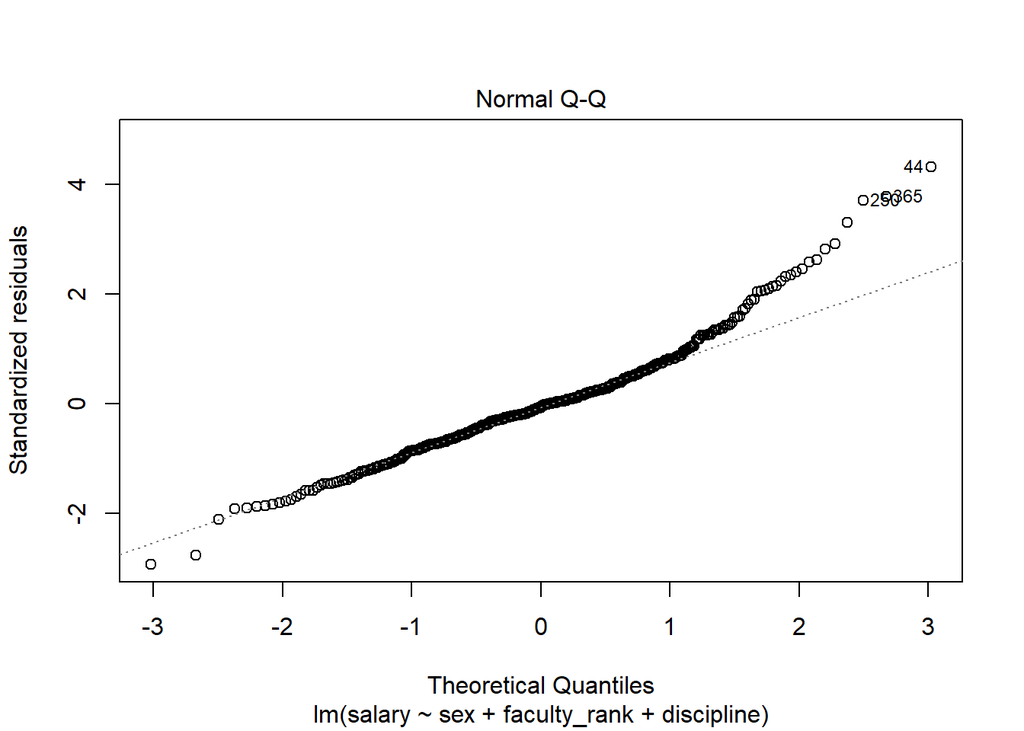

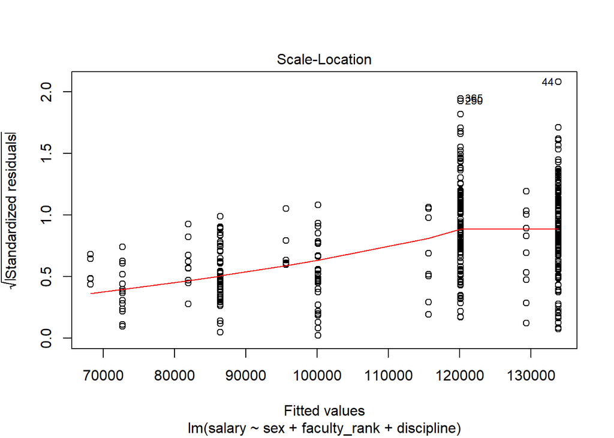

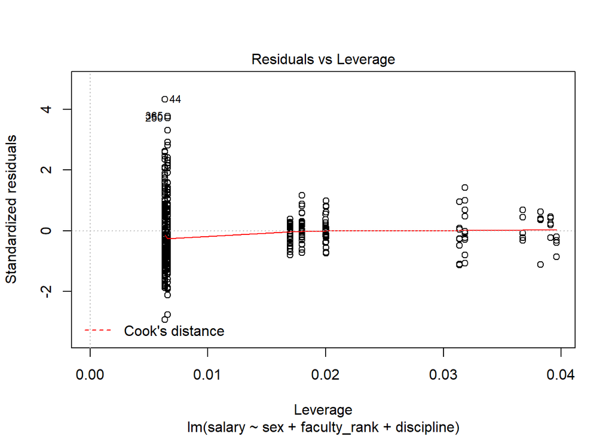

```r
plot(salary_lm3)
```